# Lab 1: Data Cleaning

## RJ Nowling

In this lab, we are loading a data set of real state transctions and cleaning it.

```python
import matplotlib.pyplot as plt
import pandas as pd
import seaborn as sns
```

## Part 1: Load and View Data

```python
df = pd.read_csv("Sacramentorealestatetransactions.csv")
```

```python
df.head(10)
```

|  | street | city | zip | state | beds | baths | sq__ft | type | sale_date | price | latitude | longitude |
| --- | --- | --- | --- | --- | --- | --- | --- | --- | --- | --- | --- | --- |
| 0 | 3526 HIGH ST | SACRAMENTO | 95838 | CA | 2 | 1 | 836 | Residential | Wed May 21 00:00:00 EDT 2008 | 59222 | 38.631913 | -121.434879 |
| 1 | 51 OMAHA CT | SACRAMENTO | 95823 | CA | 3 | 1 | 1167 | Residential | Wed May 21 00:00:00 EDT 2008 | 68212 | 38.478902 | -121.431028 |
| 2 | 2796 BRANCH ST | SACRAMENTO | 95815 | CA | 2 | 1 | 796 | Residential | Wed May 21 00:00:00 EDT 2008 | 68880 | 38.618305 | -121.443839 |
| 3 | 2805 JANETTE WAY | SACRAMENTO | 95815 | CA | 2 | 1 | 852 | Residential | Wed May 21 00:00:00 EDT 2008 | 69307 | 38.616835 | -121.439146 |
| 4 | 6001 MCMAHON DR | SACRAMENTO | 95824 | CA | 2 | 1 | 797 | Residential | Wed May 21 00:00:00 EDT 2008 | 81900 | 38.519470 | -121.435768 |
| 5 | 5828 PEPPERMILL CT | SACRAMENTO | 95841 | CA | 3 | 1 | 1122 | Condo | Wed May 21 00:00:00 EDT 2008 | 89921 | 38.662595 | -121.327813 |
| 6 | 6048 OGDEN NASH WAY | SACRAMENTO | 95842 | CA | 3 | 2 | 1104 | Residential | Wed May 21 00:00:00 EDT 2008 | 90895 | 38.681659 | -121.351705 |
| 7 | 2561 19TH AVE | SACRAMENTO | 95820 | CA | 3 | 1 | 1177 | Residential | Wed May 21 00:00:00 EDT 2008 | 91002 | 38.535092 | -121.481367 |
| 8 | 11150 TRINITY RIVER DR Unit 114 | RANCHO CORDOVA | 95670 | CA | 2 | 2 | 941 | Condo | Wed May 21 00:00:00 EDT 2008 | 94905 | 38.621188 | -121.270555 |
| 9 | 7325 10TH ST | RIO LINDA | 95673 | CA | 3 | 2 | 1146 | Residential | Wed May 21 00:00:00 EDT 2008 | 98937 | 38.700909 | -121.442979 |

```python
df.info()
```

```
<class 'pandas.core.frame.DataFrame'>
RangeIndex: 985 entries, 0 to 984
Data columns (total 12 columns):
 #   Column     Non-Null Count  Dtype
---  ------     --------------  -----
 0   street     985 non-null    object
 1   city       985 non-null    object
 2   zip        985 non-null    int64
 3   state      985 non-null    object
 4   beds       985 non-null    int64
 5   baths      985 non-null    int64
 6   sq__ft     985 non-null    int64
 7   type       985 non-null    object
 8   sale_date  985 non-null    object
 9   price      985 non-null    int64
 10  latitude   985 non-null    float64
 11  longitude  985 non-null    float64
dtypes: float64(2), int64(5), object(5)
memory usage: 92.5+ KB
```

The data set contains 12 columns. None of the columns have null values. There are two float-valued columns (latitude and longitude), 5 integer-valued columns (zip, beds, baths, sq__ft, and price), and 5 columns (street, city, state, type, sale_date) of type "object". The objects are most likely strings.

## Part 2: Categorical Variables

```python
print("Streets:", len(set(df["street"])))
print("City:", len(set(df["city"])))
print("Zip:", len(set(df["zip"])))
print("State:", len(set(df["state"])))
print("beds:", len(set(df["beds"])))
print("baths:", len(set(df["baths"])))
print("type:", len(set(df["type"])))
```

```
Streets: 981
City: 39
Zip: 68
State: 1
beds: 8
baths: 6
type: 4
```

I printed out the number of unique values for columns that I thought could be represented as categorical variables. The number of unique values for the streets, zip codes, and cities are quite high so these may not be good categorical variables. There is only one state, so that probably won't be a useful variable but we can make it categorical. The number of beds, baths, and types all look like good categorical variables.

```python
for col in ["city", "zip", "state", "beds", "baths", "type"]:
    df[col] = df[col].astype("category")
```

```python
df.info()
```

```
<class 'pandas.core.frame.DataFrame'>
RangeIndex: 985 entries, 0 to 984
Data columns (total 12 columns):
 #   Column     Non-Null Count  Dtype
---  ------     --------------  -----
 0   street     985 non-null    object
 1   city       985 non-null    category
 2   zip        985 non-null    category
 3   state      985 non-null    category
 4   beds       985 non-null    category
 5   baths      985 non-null    category
 6   sq__ft     985 non-null    int64
 7   type       985 non-null    category
 8   sale_date  985 non-null    object
 9   price      985 non-null    int64
 10  latitude   985 non-null    float64
 11  longitude  985 non-null    float64
dtypes: category(6), float64(2), int64(2), object(2)
memory usage: 57.5+ KB
```

The columns were correctly converted to categorical variables.

## Part 3: Continuous Variables

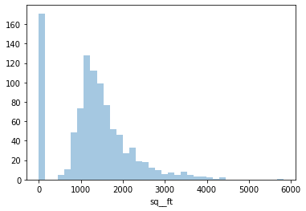

```python
sns.distplot(df["sq__ft"], kde=False)
```

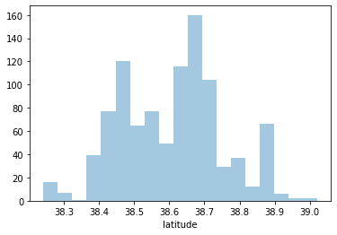

```python
sns.distplot(df["latitude"], kde=False)
```

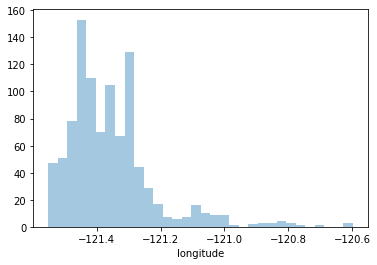

```python
sns.distplot(df["longitude"], kde=False)
```

I plotted the three variables. I chose histograms since the variables are continuous. The latitude and longitude variables do not look too exciting. The square footage has a number of records with values of 0, which is weird. I think these records are for empty lots (no building).

## Part 4: Categorical Variables

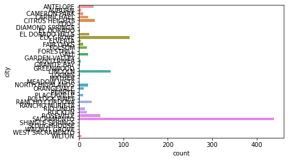

```python
sns.countplot(y="city", data=df)
```

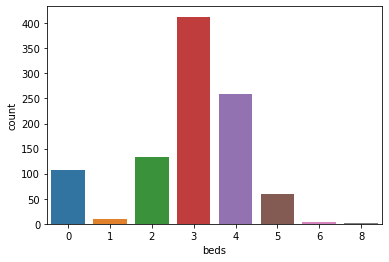

```python
sns.countplot(x="beds", data=df)
```

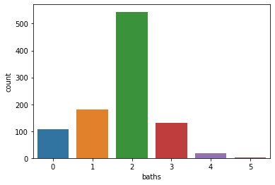

```python
sns.countplot(x="baths", data=df)
```

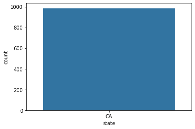

```python
sns.countplot(x="state", data=df)
```

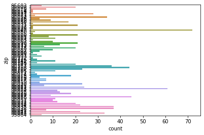

```python
sns.countplot(y="zip", data=df)
```

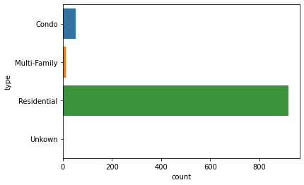

```python
sns.countplot(y="type", data=df)
```

According to the type variable, the data set contains condos, multi-family, and residential homes as well as a few properties with an "unkown" type. It is weird to me that any of the properties would have 0 bedrooms or bathrooms then. I suspect that these may be empty lots.

## Part 5: Empty Lot Variable

Since we suspect that some of the entries are for empty lots, we are going to create a new boolean variable to identify those records.

```python
df["empty_lot"] = False
mask = df["sq__ft"] == 0
df.loc[mask, "empty_lot"] = True
```

```python
df.info()
```

```
<class 'pandas.core.frame.DataFrame'>
RangeIndex: 985 entries, 0 to 984
Data columns (total 13 columns):
 #   Column     Non-Null Count  Dtype
---  ------     --------------  -----
 0   street     985 non-null    object
 1   city       985 non-null    category
 2   zip        985 non-null    category
 3   state      985 non-null    category
 4   beds       985 non-null    category
 5   baths      985 non-null    category
 6   sq__ft     985 non-null    int64
 7   type       985 non-null    category
 8   sale_date  985 non-null    object
 9   price      985 non-null    int64
 10  latitude   985 non-null    float64
 11  longitude  985 non-null    float64
 12  empty_lot  985 non-null    bool
dtypes: bool(1), category(6), float64(2), int64(2), object(2)
memory usage: 58.5+ KB
```

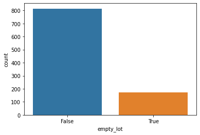

```python
sns.countplot(x="empty_lot", data=df)
```

I successfully created an additional column with a boolean type.

## Part 6: Street Types

The street address are strings and unique to each property. They would not be useful as a variable as they are now. I am going to parse them to get the street type (e.g., avenue) from each address.

```python
def parse_address_1(address):
    if "Unit" in address:
        idx = address.find("Unit")
        # cut off " Unit ..." from the end of the address
        address = address[:idx - 1]
    address = address.upper()
    cols = address.split()
    # Assume the last entry is the street type
    return cols[-1]
```

```python
street_types = df["street"].apply(parse_address_1)
print(set(street_types))
```

```
{'AVE', 'TRAK', 'DR', 'MARTINA', 'CIR', 'MADERA', '193', 'PKWY', 'GRANDE', 'LN', 'HL', 'WAY', 'CT', 'BLVD', 'TRL', 'CONEJO', 'LOOP', 'PL', 'ST', 'BROADWAY', 'WALK', 'RD'}
```

In my first attempt, I got a number of street types but also a few addresses that I am not parsing correctly.

- 1813 AVENIDA MARTINA
- 3720 VISTA DE MADERA
- 9970 STATE HIGHWAY 193
- 6306 CONEJO

I am going to treet these as special cases.

```python
def parse_address_2(address):
    if "Unit" in address:
        idx = address.find("Unit")
        # cut off " Unit ..." from the end of the address
        address = address[:idx - 1]
    address = address.upper()

    if "AVENIDA" in address:
        return "AVE"

    if "VISTA" in address:
        return "VISTA"

    if "STATE HIGHWAY" in address:
        return "HWY"

    if "CONEJO" in address:
        return "Unknown"

    cols = address.split()
    # Assume the last entry is the street type
    return cols[-1]
```

```python
street_types = df["street"].apply(parse_address_2)
print(set(street_types))
```

```
{'VISTA', 'AVE', 'TRAK', 'DR', 'CIR', 'HWY', 'PKWY', 'GRANDE', 'LN', 'HL', 'WAY', 'CT', 'BLVD', 'TRL', 'Unknown', 'LOOP', 'PL', 'ST', 'BROADWAY', 'WALK', 'RD'}
```

```python
df["street_type"] = street_types
df.info()
```

```
<class 'pandas.core.frame.DataFrame'>
RangeIndex: 985 entries, 0 to 984
Data columns (total 14 columns):
 #   Column       Non-Null Count  Dtype
---  ------       --------------  -----
 0   street       985 non-null    object
 1   city         985 non-null    category
 2   zip          985 non-null    category
 3   state        985 non-null    category
 4   beds         985 non-null    category
 5   baths        985 non-null    category
 6   sq__ft       985 non-null    int64
 7   type         985 non-null    category
 8   sale_date    985 non-null    object
 9   price        985 non-null    int64
 10  latitude     985 non-null    float64
 11  longitude    985 non-null    float64
 12  empty_lot    985 non-null    bool
 13  street_type  985 non-null    object
dtypes: bool(1), category(6), float64(2), int64(2), object(3)
memory usage: 66.2+ KB
```

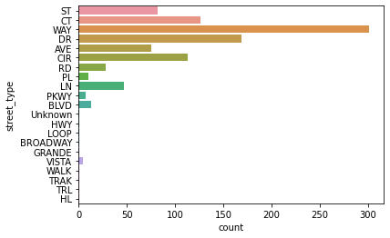

```python
sns.countplot(y="street_type", data=df)
```

I was able to parse all of the street types except for one address. I may consider removing that record as an outlier. Street, court, way, drive, avenue, circle, lane, and road seem to be the most common street types THere are a few places, parkways, and boulevards, too. The rest probably only belong to handful of records.

## Part 7: Identifying Possible Dependent Variables

I think that the price of the property would make a good dependent variable. Many real estate web sites estimate the sale prices of properties to help owners determine how much to offer. I think that would be a useful regression model to create with this data set.

For a classification problem, I think it would be interesting to try to predict the type of the property. This should be easy to predict from the number of bedrooms and bathrooms.

## Part 8: Save Data

I'm going to save my cleaned data set to a file. But first I want to remove two outlier records I found.

```python
mask = (df["type"] == "Unkown") | (df["street_type"] == "Unknown")
df = df[~mask]

df.info()
```

```
<class 'pandas.core.frame.DataFrame'>
Int64Index: 983 entries, 0 to 984
Data columns (total 14 columns):
 #   Column       Non-Null Count  Dtype
---  ------       --------------  -----
 0   street       983 non-null    object
 1   city         983 non-null    category
 2   zip          983 non-null    category
 3   state        983 non-null    category
 4   beds         983 non-null    category
 5   baths        983 non-null    category
 6   sq__ft       983 non-null    int64
 7   type         983 non-null    category
 8   sale_date    983 non-null    object
 9   price        983 non-null    int64
 10  latitude     983 non-null    float64
 11  longitude    983 non-null    float64
 12  empty_lot    983 non-null    bool
 13  street_type  983 non-null    object
dtypes: bool(1), category(6), float64(2), int64(2), object(3)
memory usage: 73.6+ KB
```

My data set went from 985 to 983 entries -- I successfully removed the two outlier records without dropping any records I wanted to keep.

```python
df.to_csv("cleaned_data.csv", index=False)
```